# Solving Ordinary Differential Equations

A Comparison of Python and Octave

Author

Magnificus Rex

## Introduction

This document demonstrates how to solve Ordinary Differential Equations (ODEs) using both Python and Octave. We’ll explore several classic examples including:

1. Simple exponential decay
2. Harmonic oscillator (mass-spring system)
3. Predator-prey dynamics (Lotka-Volterra)
4. The Lorenz system (chaotic dynamics)

## Numerical Methods Overview

Before diving into examples, let’s understand the numerical methods used to solve ODEs. We’ll implement and compare three fundamental methods:

1. **Forward Euler** - First-order method (simple but less accurate)
2. **Runge-Kutta 4th order (RK4)** - Fourth-order method (classic, highly accurate)
3. **Adaptive solvers** - Variable step-size methods (most efficient)

### Python Implementation of Numerical Methods

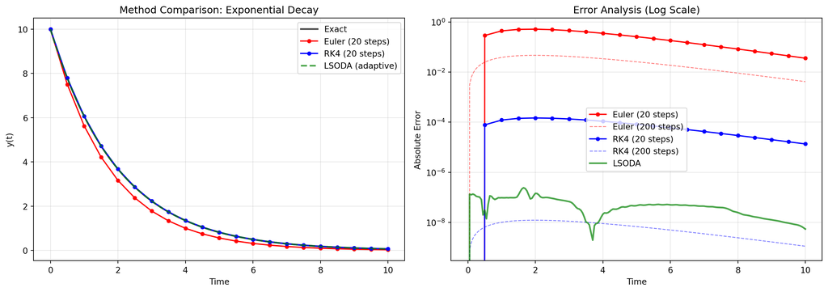

```
Final Errors at t=10:
  Euler (20 steps):  3.566735e-02
  Euler (200 steps): 4.149476e-03
  RK4 (20 steps):    1.351641e-05
  RK4 (200 steps):   1.119765e-09
  LSODA (adaptive):  5.426792e-09
```

```python
import numpy as np
import matplotlib.pyplot as plt
from scipy.integrate import odeint

def euler_method(f, y0, t, *args):
    """
    Forward Euler method for solving ODEs.

    dy/dt = f(y, t, *args)
    y(t0) = y0
    """
    y = np.zeros((len(t), len(y0) if hasattr(y0, '__len__') else 1))
    y[0] = y0

    for i in range(len(t) - 1):
        dt = t[i+1] - t[i]
        y[i+1] = y[i] + dt * np.array(f(y[i], t[i], *args))

    return y

def rk4_method(f, y0, t, *args):
    """
    4th order Runge-Kutta method for solving ODEs.

    dy/dt = f(y, t, *args)
    y(t0) = y0
    """
    y = np.zeros((len(t), len(y0) if hasattr(y0, '__len__') else 1))
    y[0] = y0

    for i in range(len(t) - 1):
        dt = t[i+1] - t[i]
        k1 = np.array(f(y[i], t[i], *args))
        k2 = np.array(f(y[i] + dt*k1/2, t[i] + dt/2, *args))
        k3 = np.array(f(y[i] + dt*k2/2, t[i] + dt/2, *args))
        k4 = np.array(f(y[i] + dt*k3, t[i] + dt, *args))

        y[i+1] = y[i] + (dt/6) * (k1 + 2*k2 + 2*k3 + k4)

    return y

# Test with exponential decay
def decay_ode(y, t, k):
    return -k * y

k = 0.5
y0 = [10.0]
t_coarse = np.linspace(0, 10, 21)  # 20 steps
t_fine = np.linspace(0, 10, 201)   # 200 steps

# Analytical solution
y_exact = y0[0] * np.exp(-k * t_fine)

# Solve with different methods
y_euler_coarse = euler_method(decay_ode, y0, t_coarse, k)
y_euler_fine = euler_method(decay_ode, y0, t_fine, k)
y_rk4_coarse = rk4_method(decay_ode, y0, t_coarse, k)
y_rk4_fine = rk4_method(decay_ode, y0, t_fine, k)
y_odeint = odeint(decay_ode, y0, t_fine, args=(k,))

# Plot comparison
fig, (ax1, ax2) = plt.subplots(1, 2, figsize=(14, 5))

# Left plot: Visual comparison
ax1.plot(t_fine, y_exact, 'k-', linewidth=2, label='Exact', alpha=0.7)
ax1.plot(t_coarse, y_euler_coarse, 'r.-', linewidth=1.5, markersize=8, label='Euler (20 steps)')
ax1.plot(t_coarse, y_rk4_coarse, 'b.-', linewidth=1.5, markersize=8, label='RK4 (20 steps)')
ax1.plot(t_fine, y_odeint, 'g--', linewidth=2, label='LSODA (adaptive)', alpha=0.7)
ax1.set_xlabel('Time')
ax1.set_ylabel('y(t)')
ax1.set_title('Method Comparison: Exponential Decay')
ax1.legend()
ax1.grid(True, alpha=0.3)

# Right plot: Error analysis
error_euler_coarse = np.abs(y_euler_coarse.flatten() - y0[0] * np.exp(-k * t_coarse))
error_euler_fine = np.abs(y_euler_fine.flatten() - y_exact)
error_rk4_coarse = np.abs(y_rk4_coarse.flatten() - y0[0] * np.exp(-k * t_coarse))
error_rk4_fine = np.abs(y_rk4_fine.flatten() - y_exact)
error_odeint = np.abs(y_odeint.flatten() - y_exact)

ax2.semilogy(t_coarse, error_euler_coarse, 'r.-', linewidth=1.5, markersize=8, label='Euler (20 steps)')
ax2.semilogy(t_fine, error_euler_fine, 'r--', linewidth=1, alpha=0.5, label='Euler (200 steps)')
ax2.semilogy(t_coarse, error_rk4_coarse, 'b.-', linewidth=1.5, markersize=8, label='RK4 (20 steps)')
ax2.semilogy(t_fine, error_rk4_fine, 'b--', linewidth=1, alpha=0.5, label='RK4 (200 steps)')
ax2.semilogy(t_fine, error_odeint, 'g-', linewidth=2, label='LSODA', alpha=0.7)
ax2.set_xlabel('Time')
ax2.set_ylabel('Absolute Error')
ax2.set_title('Error Analysis (Log Scale)')
ax2.legend()
ax2.grid(True, alpha=0.3)

plt.tight_layout()
plt.show()

# Print final errors
print("Final Errors at t=10:")
print(f"  Euler (20 steps):  {error_euler_coarse[-1]:.6e}")
print(f"  Euler (200 steps): {error_euler_fine[-1]:.6e}")
print(f"  RK4 (20 steps):    {error_rk4_coarse[-1]:.6e}")
print(f"  RK4 (200 steps):   {error_rk4_fine[-1]:.6e}")
print(f"  LSODA (adaptive):  {error_odeint[-1]:.6e}")
```

### Octave Implementation of Numerical Methods

```matlab
#| eval: false
% Forward Euler method
function y = euler_method(f, y0, t, varargin)
    n = length(t);
    m = length(y0);
    y = zeros(n, m);
    y(1, :) = y0;

    for i = 1:n-1
        dt = t(i+1) - t(i);
        y(i+1, :) = y(i, :) + dt * f(y(i, :)', t(i), varargin{:})';
    end
end

% 4th order Runge-Kutta method
function y = rk4_method(f, y0, t, varargin)
    n = length(t);
    m = length(y0);
    y = zeros(n, m);
    y(1, :) = y0;

    for i = 1:n-1
        dt = t(i+1) - t(i);
        k1 = f(y(i, :)', t(i), varargin{:});
        k2 = f(y(i, :)' + dt*k1/2, t(i) + dt/2, varargin{:});
        k3 = f(y(i, :)' + dt*k2/2, t(i) + dt/2, varargin{:});
        k4 = f(y(i, :)' + dt*k3, t(i) + dt, varargin{:});

        y(i+1, :) = y(i, :) + (dt/6) * (k1 + 2*k2 + 2*k3 + k4)';
    end
end

% Test with exponential decay
function dydt = decay_ode(y, t, k)
    dydt = -k * y;
end

k = 0.5;
y0 = 10.0;
t_coarse = linspace(0, 10, 21);
t_fine = linspace(0, 10, 201);

% Analytical solution
y_exact = y0 * exp(-k * t_fine);

% Solve with different methods
y_euler_coarse = euler_method(@decay_ode, y0, t_coarse, k);
y_rk4_coarse = rk4_method(@decay_ode, y0, t_coarse, k);
y_lsode = lsode(@(y, t) decay_ode(y, t, k), y0, t_fine);

% Plot comparison
figure;
subplot(1, 2, 1);
plot(t_fine, y_exact, 'k-', 'LineWidth', 2);
hold on;
plot(t_coarse, y_euler_coarse, 'r.-', 'LineWidth', 1.5, 'MarkerSize', 8);
plot(t_coarse, y_rk4_coarse, 'b.-', 'LineWidth', 1.5, 'MarkerSize', 8);
plot(t_fine, y_lsode, 'g--', 'LineWidth', 2);
xlabel('Time');
ylabel('y(t)');
title('Method Comparison: Exponential Decay');
legend('Exact', 'Euler (20 steps)', 'RK4 (20 steps)', 'LSODE');
grid on;

% Error analysis
subplot(1, 2, 2);
error_euler = abs(y_euler_coarse - y0 * exp(-k * t_coarse)');
error_rk4 = abs(y_rk4_coarse - y0 * exp(-k * t_coarse)');
error_lsode = abs(y_lsode - y_exact');

semilogy(t_coarse, error_euler, 'r.-', 'LineWidth', 1.5, 'MarkerSize', 8);
hold on;
semilogy(t_coarse, error_rk4, 'b.-', 'LineWidth', 1.5, 'MarkerSize', 8);
semilogy(t_fine, error_lsode, 'g-', 'LineWidth', 2);
xlabel('Time');
ylabel('Absolute Error');
title('Error Analysis (Log Scale)');
legend('Euler (20 steps)', 'RK4 (20 steps)', 'LSODE');
grid on;
```

### Key Observations

From the comparison above, we can see:

1. **Euler Method**:
   - Simplest to implement
   - First-order accuracy: error ∝ Δt
   - Requires many small steps for accuracy
   - Can accumulate significant error over time
2. **RK4 Method**:
   - More complex but still straightforward
   - Fourth-order accuracy: error ∝ Δt⁴
   - Much more accurate than Euler for the same step size
   - Good balance of accuracy and efficiency
3. **Adaptive Solvers (LSODA/odeint)**:
   - Automatically adjust step size
   - Use error estimation to maintain accuracy
   - Most efficient for complex problems
   - Handle stiff equations better

### When to Use Each Method

- **Euler**: Educational purposes, extremely simple systems, or when implementing custom methods
- **RK4**: Good baseline for custom implementations, fixed time-step requirements
- **Adaptive Solvers**: Production code, complex systems, when you need reliability and efficiency

## Example 1: Exponential Decay

The simplest ODE describes exponential decay:

$$\frac{dy}{dt} = -ky$$

with initial condition $y(0) = y_0$.

### Python Solution

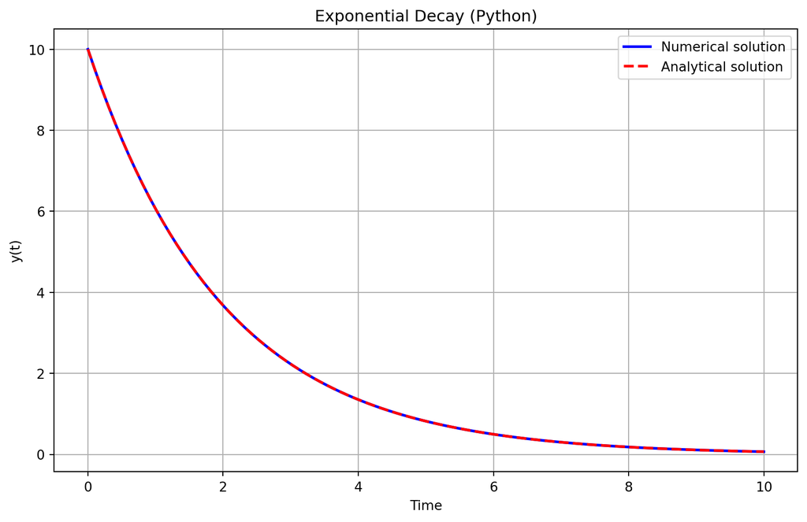

```python
import numpy as np
import matplotlib.pyplot as plt
from scipy.integrate import odeint

# Define the ODE
def exponential_decay(y, t, k):
    return -k * y

# Parameters
k = 0.5
y0 = 10
t = np.linspace(0, 10, 100)

# Solve ODE
y = odeint(exponential_decay, y0, t, args=(k,))

# Plot
plt.figure(figsize=(10, 6))
plt.plot(t, y, 'b-', linewidth=2, label='Numerical solution')
plt.plot(t, y0 * np.exp(-k*t), 'r--', linewidth=2, label='Analytical solution')
plt.xlabel('Time')
plt.ylabel('y(t)')
plt.title('Exponential Decay (Python)')
plt.legend()
plt.grid(True)
plt.show()
```

### Octave Solution

```matlab
#| eval: false
% Define the ODE
function dydt = exponential_decay(y, t, k)
    dydt = -k * y;
endfunction

% Parameters
k = 0.5;
y0 = 10;
t = linspace(0, 10, 100);

% Solve ODE
y = lsode(@(y, t) exponential_decay(y, t, k), y0, t);

% Plot
figure;
plot(t, y, 'b-', 'LineWidth', 2);
hold on;
plot(t, y0 * exp(-k*t), 'r--', 'LineWidth', 2);
xlabel('Time');
ylabel('y(t)');
title('Exponential Decay (Octave)');
legend('Numerical solution', 'Analytical solution');
grid on;
```

## Example 2: Harmonic Oscillator

The classic mass-spring system is described by:

$$\frac{d^2x}{dt^2} + 2\zeta\omega_0\frac{dx}{dt} + \omega_0^2x = 0$$

We convert this to a system of first-order ODEs.

### Python Solution

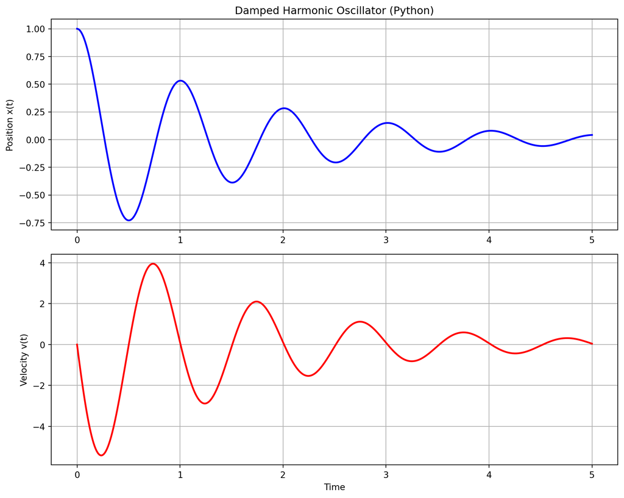

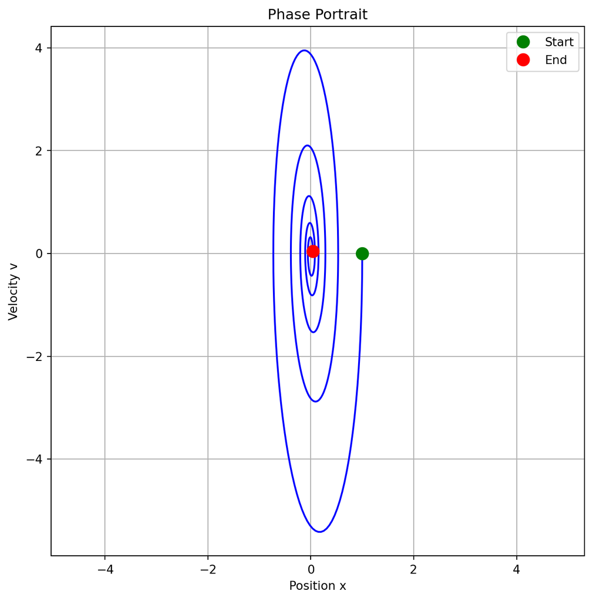

```python
# Define the harmonic oscillator system
def harmonic_oscillator(y, t, zeta, omega0):
    x, v = y
    dxdt = v
    dvdt = -2*zeta*omega0*v - omega0**2*x
    return [dxdt, dvdt]

# Parameters: underdamped oscillator
zeta = 0.1  # damping ratio
omega0 = 2*np.pi  # natural frequency
y0 = [1, 0]  # initial position and velocity
t = np.linspace(0, 5, 500)

# Solve ODE
solution = odeint(harmonic_oscillator, y0, t, args=(zeta, omega0))
x = solution[:, 0]
v = solution[:, 1]

# Plot position and velocity
fig, (ax1, ax2) = plt.subplots(2, 1, figsize=(10, 8))

ax1.plot(t, x, 'b-', linewidth=2)
ax1.set_ylabel('Position x(t)')
ax1.set_title('Damped Harmonic Oscillator (Python)')
ax1.grid(True)

ax2.plot(t, v, 'r-', linewidth=2)
ax2.set_xlabel('Time')
ax2.set_ylabel('Velocity v(t)')
ax2.grid(True)

plt.tight_layout()
plt.show()

# Phase portrait
plt.figure(figsize=(8, 8))
plt.plot(x, v, 'b-', linewidth=1.5)
plt.plot(x[0], v[0], 'go', markersize=10, label='Start')
plt.plot(x[-1], v[-1], 'ro', markersize=10, label='End')
plt.xlabel('Position x')
plt.ylabel('Velocity v')
plt.title('Phase Portrait')
plt.legend()
plt.grid(True)
plt.axis('equal')
plt.show()
```

### Octave Solution

```matlab
#| eval: false
% Define the harmonic oscillator system
function dydt = harmonic_oscillator(y, t, zeta, omega0)
    x = y(1);
    v = y(2);
    dxdt = v;
    dvdt = -2*zeta*omega0*v - omega0^2*x;
    dydt = [dxdt; dvdt];
endfunction

% Parameters
zeta = 0.1;
omega0 = 2*pi;
y0 = [1; 0];
t = linspace(0, 5, 500);

% Solve ODE
solution = lsode(@(y, t) harmonic_oscillator(y, t, zeta, omega0), y0, t);
x = solution(:, 1);
v = solution(:, 2);

% Plot position and velocity
figure;
subplot(2, 1, 1);
plot(t, x, 'b-', 'LineWidth', 2);
ylabel('Position x(t)');
title('Damped Harmonic Oscillator (Octave)');
grid on;

subplot(2, 1, 2);
plot(t, v, 'r-', 'LineWidth', 2);
xlabel('Time');
ylabel('Velocity v(t)');
grid on;
```

## Example 3: Predator-Prey Dynamics

The Lotka-Volterra equations model population dynamics:

$$\frac{dx}{dt} = \alpha x - \beta xy$$
$$\frac{dy}{dt} = \delta xy - \gamma y$$

where $x$ is prey population and $y$ is predator population.

### Python Solution

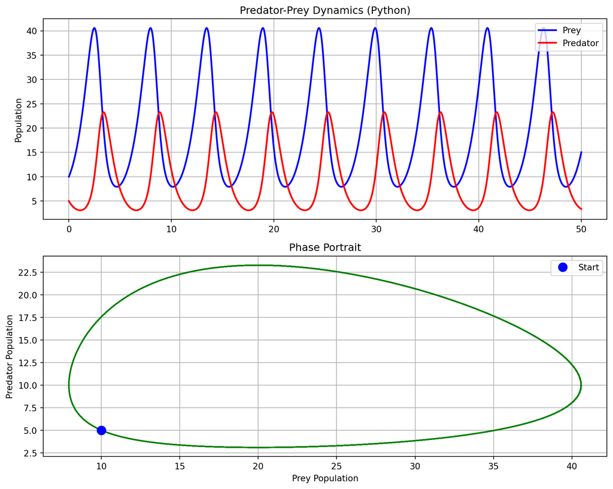

```python
# Define Lotka-Volterra equations
def lotka_volterra(y, t, alpha, beta, delta, gamma):
    x, y_pred = y
    dxdt = alpha*x - beta*x*y_pred
    dydt = delta*x*y_pred - gamma*y_pred
    return [dxdt, dydt]

# Parameters
alpha = 1.0   # prey birth rate
beta = 0.1    # predation rate
delta = 0.075 # predator efficiency
gamma = 1.5   # predator death rate
y0 = [10, 5]  # initial populations
t = np.linspace(0, 50, 1000)

# Solve ODE
solution = odeint(lotka_volterra, y0, t, args=(alpha, beta, delta, gamma))
prey = solution[:, 0]
predator = solution[:, 1]

# Plot time series
fig, (ax1, ax2) = plt.subplots(2, 1, figsize=(10, 8))

ax1.plot(t, prey, 'b-', linewidth=2, label='Prey')
ax1.plot(t, predator, 'r-', linewidth=2, label='Predator')
ax1.set_ylabel('Population')
ax1.set_title('Predator-Prey Dynamics (Python)')
ax1.legend()
ax1.grid(True)

# Phase portrait
ax2.plot(prey, predator, 'g-', linewidth=1.5)
ax2.plot(prey[0], predator[0], 'bo', markersize=10, label='Start')
ax2.set_xlabel('Prey Population')
ax2.set_ylabel('Predator Population')
ax2.set_title('Phase Portrait')
ax2.legend()
ax2.grid(True)

plt.tight_layout()
plt.show()
```

### Octave Solution

```matlab
#| eval: false
% Define Lotka-Volterra equations
function dydt = lotka_volterra(y, t, alpha, beta, delta, gamma)
    x = y(1);
    y_pred = y(2);
    dxdt = alpha*x - beta*x*y_pred;
    dydt = delta*x*y_pred - gamma*y_pred;
    dydt = [dxdt; dydt];
endfunction

% Parameters
alpha = 1.0;
beta = 0.1;
delta = 0.075;
gamma = 1.5;
y0 = [10; 5];
t = linspace(0, 50, 1000);

% Solve ODE
solution = lsode(@(y, t) lotka_volterra(y, t, alpha, beta, delta, gamma), y0, t);
prey = solution(:, 1);
predator = solution(:, 2);

% Plot
figure;
subplot(2, 1, 1);
plot(t, prey, 'b-', 'LineWidth', 2);
hold on;
plot(t, predator, 'r-', 'LineWidth', 2);
ylabel('Population');
title('Predator-Prey Dynamics (Octave)');
legend('Prey', 'Predator');
grid on;

subplot(2, 1, 2);
plot(prey, predator, 'g-', 'LineWidth', 1.5);
xlabel('Prey Population');
ylabel('Predator Population');
title('Phase Portrait');
grid on;
```

## Example 4: Lorenz System

The Lorenz system is a classic example of chaotic dynamics:

$$\frac{dx}{dt} = \sigma(y - x)$$
$$\frac{dy}{dt} = x(\rho - z) - y$$
$$\frac{dz}{dt} = xy - \beta z$$

### Python Solution

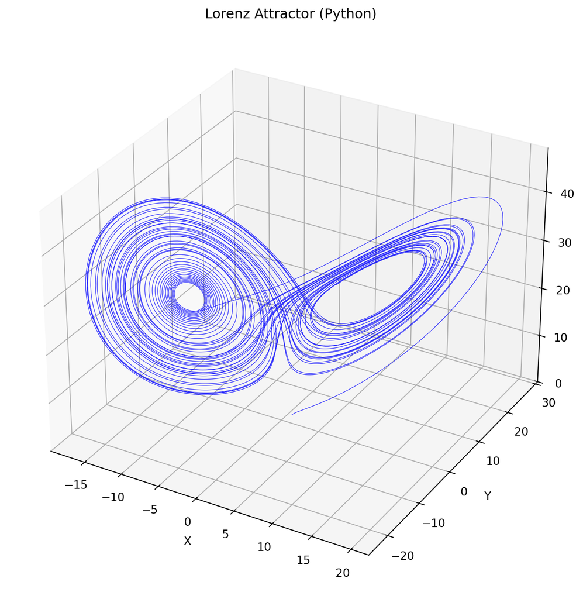

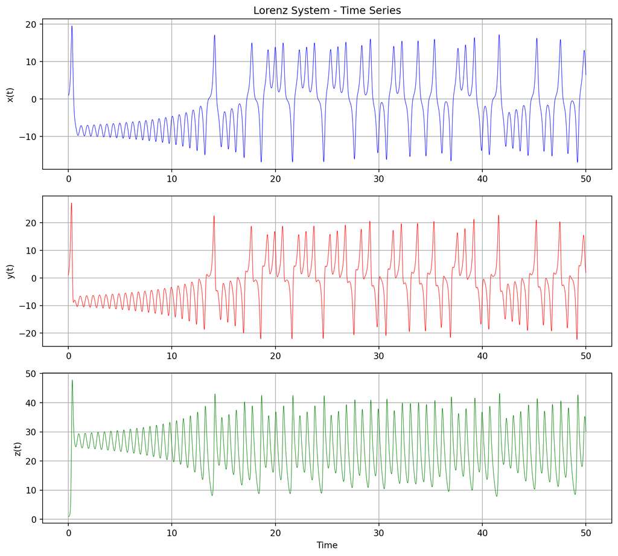

```python
from mpl_toolkits.mplot3d import Axes3D

# Define Lorenz system
def lorenz(y, t, sigma, rho, beta):
    x, y_coord, z = y
    dxdt = sigma * (y_coord - x)
    dydt = x * (rho - z) - y_coord
    dzdt = x * y_coord - beta * z
    return [dxdt, dydt, dzdt]

# Parameters (classic chaotic regime)
sigma = 10.0
rho = 28.0
beta = 8.0/3.0
y0 = [1, 1, 1]
t = np.linspace(0, 50, 10000)

# Solve ODE
solution = odeint(lorenz, y0, t, args=(sigma, rho, beta))
x = solution[:, 0]
y_coord = solution[:, 1]
z = solution[:, 2]

# 3D Plot
fig = plt.figure(figsize=(12, 9))
ax = fig.add_subplot(111, projection='3d')
ax.plot(x, y_coord, z, 'b-', linewidth=0.5, alpha=0.8)
ax.set_xlabel('X')
ax.set_ylabel('Y')
ax.set_zlabel('Z')
ax.set_title('Lorenz Attractor (Python)')
plt.show()

# Time series
fig, (ax1, ax2, ax3) = plt.subplots(3, 1, figsize=(10, 9))

ax1.plot(t, x, 'b-', linewidth=0.5)
ax1.set_ylabel('x(t)')
ax1.set_title('Lorenz System - Time Series')
ax1.grid(True)

ax2.plot(t, y_coord, 'r-', linewidth=0.5)
ax2.set_ylabel('y(t)')
ax2.grid(True)

ax3.plot(t, z, 'g-', linewidth=0.5)
ax3.set_xlabel('Time')
ax3.set_ylabel('z(t)')
ax3.grid(True)

plt.tight_layout()
plt.show()
```

### Octave Solution

```matlab
#| eval: false
% Define Lorenz system
function dydt = lorenz(y, t, sigma, rho, beta)
    x = y(1);
    y_coord = y(2);
    z = y(3);
    dxdt = sigma * (y_coord - x);
    dydt = x * (rho - z) - y_coord;
    dzdt = x * y_coord - beta * z;
    dydt = [dxdt; dydt; dzdt];
endfunction

% Parameters
sigma = 10.0;
rho = 28.0;
beta = 8.0/3.0;
y0 = [1; 1; 1];
t = linspace(0, 50, 10000);

% Solve ODE
solution = lsode(@(y, t) lorenz(y, t, sigma, rho, beta), y0, t);
x = solution(:, 1);
y_coord = solution(:, 2);
z = solution(:, 3);

% 3D Plot
figure;
plot3(x, y_coord, z, 'b-', 'LineWidth', 0.5);
xlabel('X');
ylabel('Y');
zlabel('Z');
title('Lorenz Attractor (Octave)');
grid on;
```

## Comparison Summary

[output not shown]

### Numerical Method Performance

For the exponential decay example with 20 steps over t=[0,10]:

[output not shown]

## Conclusion

Both Python and Octave provide powerful tools for solving ODEs:

- **Python** offers more flexibility and a richer ecosystem for scientific computing
- **Octave** provides MATLAB-compatible syntax and is excellent for rapid prototyping
- Both produce accurate numerical solutions for a wide variety of ODE problems

### Key Takeaways on Numerical Methods

1. **Start with built-in solvers** - They’re optimized, tested, and handle most cases well
2. **Understand the basics** - Knowing Euler and RK4 helps you understand what’s happening under the hood
3. **Choose wisely** - Adaptive solvers (LSODA) are best for production, but simpler methods are valuable for learning
4. **Step size matters** - Euler needs many small steps; RK4 is much more efficient; adaptive solvers optimize automatically

### Recommendations

- **For learning**: Start with Euler method to understand the concept, then move to RK4
- **For research/production**: Use built-in adaptive solvers (`odeint`, `solve_ivp`, `lsode`)
- **For custom applications**: Implement RK4 if you need fixed time steps or special handling
- **For stiff problems**: Use adaptive solvers with stiff equation support (LSODA automatically handles this)

The choice between them often depends on your specific needs, existing codebase, and personal preference.